# Ayasid Data Challenge

Yan Wang

2016-08-23

## Data Overview

First take a first look at the data set.

| Variable_1 | Variable_2 | Variable_3 | Variable_1552 | Variable_1553 | class |
| --- | --- | --- | --- | --- | --- |
| -0.954246 | 0.051024 | -0.111203 | -0.369153 | 0.153795 | 0 |
| 0.244626 | -0.199602 | -0.111397 | -0.643019 | -0.014098 | 0 |
| 0.082434 | -0.156199 | -0.084980 | 0.258495 | -0.198911 | 0 |
| -1.071614 | -0.206041 | -0.051775 | -0.251188 | 0.862710 | 0 |
| -0.982276 | -0.514666 | -0.118483 | -0.677072 | 0.134160 | 0 |

### Remove missing value

Check the completed records and remove the rows with missing value. There are 2 rows contain NA value which is relativly safe to discard.

After removing the missing value, there are 270 completed records for analysis.

### Check the correlation

Looking at the relationship among variables would help to understand the data. The correlation between variables are calculated here. Sometimes the model require the factors are independent from each other, in that case we want to reduce the colinearity by removing highly correlated variables.

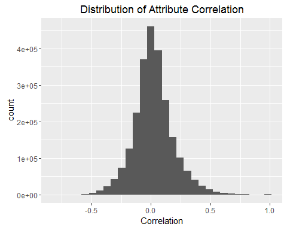

According to the distribution of correlation, most of correlations are around 0 and in bell shape. It suggests most of the variables are relatively independent from each other. However there are 79 pair of variables are highly correlated which correlation is >0.9. Probably we would like to take a further look to determine whether they are might be an issue or not. From a general perspective, it looks good since the number is few.

### Outlier detection

Local outlier factor (LOF) is used as outlier detection methods. The method defines k nearest neighbors as the locality of a given point. The distance among locality is used to estimate the local density. The points with lower density are more like outliers.

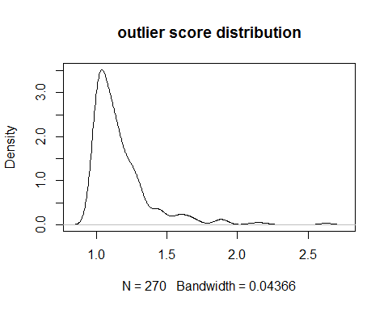

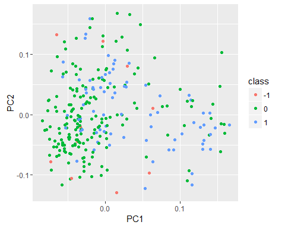

I am usually very cautious to do outlier detection. Because sometimes it is hard to tell whether an exotic point is a true outlier or just with some valuable information. Only with the good knowledge of variables, outlier detection makes more sense. So here I won’t remove those “outliers”.

## PCA

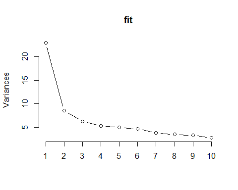

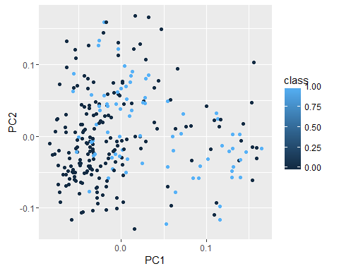

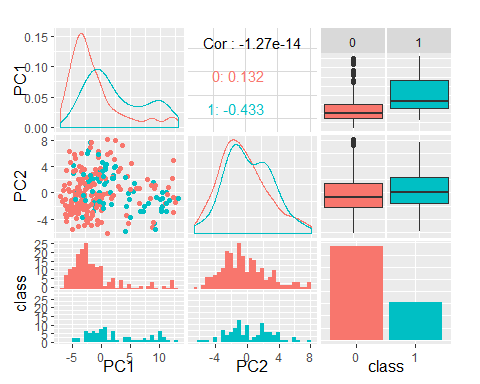

### Relationship between variables and class

Using correlation between variable and class as the statistics of its significance.

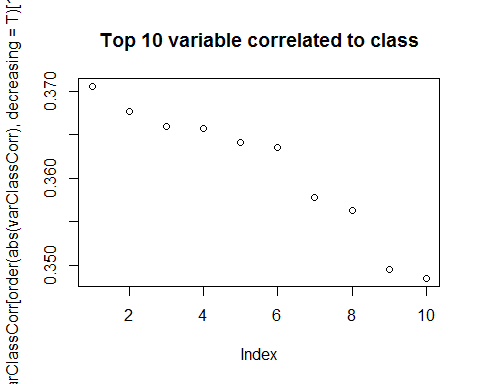

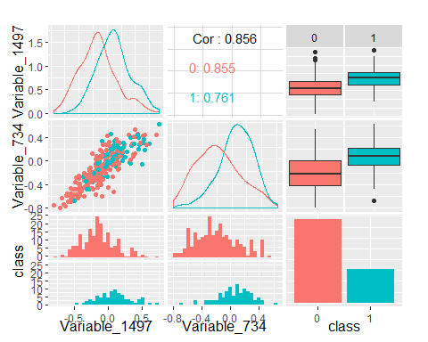

## Relationship between variables and PC1

```
## [1] 1241  578
```

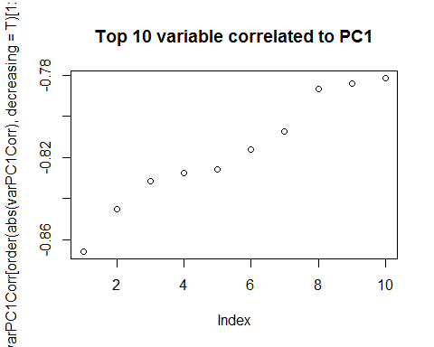

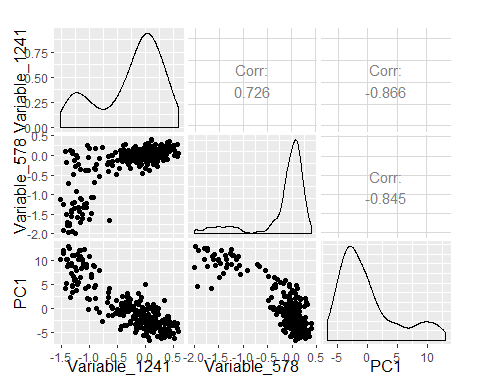

## Classification

The data set has more variables than observations. A lot of superivsed learning methods have difficulty to handle high dimentional data which causes serious overfitting. Meanwhile, we are not sure about lineariy of the real system, so most of the linear methods should be rejected. Thus, SVM and random forest is chosen here to do the classifiction. Both of the methods can handle high dimentional data well , especially when variables >> observations. And also random forest is famous for its robustness on different messy data. So it is the one worth trying most of the time.

### Separate training and testing

### SVM

SVM is designed to dealing with high dimentional data and non-linear system. It has very good performance in wide range of scenarios when data is not highly sknewed. However, when the number of variables is much higher than the observations, SVM could be overfitted. Thus variable/feature selection is important in this case. First, implement a simple SVM with tunned parameters:

```
##
## Parameter tuning of 'svm':
##
## - sampling method: 10-fold cross validation
##
## - best parameters:
##  cost gamma
##    10   0.5
##
## - best performance: 0.2078129
```

|  | 0 | 1 |
| --- | --- | --- |
| 0 | 50 | 18 |
| 1 | 0 | 0 |

#### Variable Selection

The number of variables is much larger than observations which may overfit the model if use all of them. A simple forward variable selection method is implemented to select the subset from training data set. Here are the steps:

1. Sort the variables by their correlation to `class` in descending order;
2. Start from the first variable which is the one with the highest correlation;
3. Train the SVM model with the subset of variables;
4. Tune the SVM model and estimated the error;
5. Add another variable into the training set and go back to #3;
6. Pick the subset with the lowest est. error.

Here we pick the best subset from the top 10 variables in terms of correlation to class.

Variable_1497, Variable_734, Variable_1359, Variable_1432, Variable_1086 are selected. And here is the result of using the new training set

- estimated error: 0.1852391
- test error: 0.3088235

### Random forest

Based on the random forest official website (http://www.stat.berkeley.edu/~breiman/RandomForests/cc_home.htm#remarks), Random forests is very robust against large number of variables. It is very hard to make RF overfit. Thus I don’t use any variable selection techniques. Meanwhile, random forest uses bootstraping, so there is also no need for cross-validation or separate test set. The only reason for using test set here is to give a second check.

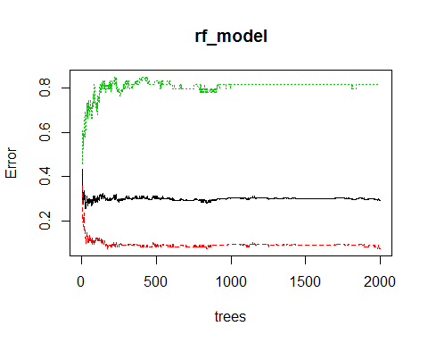

```
##
## Call:
##  randomForest(formula = as.factor(class) ~ ., data = train, importance = TRUE,      ntree = 2000)
##                Type of random forest: classification
##                      Number of trees: 2000
## No. of variables tried at each split: 39
##
##         OOB estimate of  error rate: 29.21%
## Confusion matrix:
##     0  1 class.error
## 0 132 11  0.07692308
## 1  48 11  0.81355932
```

### Conclusion

SVM - Simple Forawrd Selection

- estimated error: 0.1852391
- test error: 0.3088235

[figure not shown]

[figure not shown]

[output not shown]

[output not shown]